# Final Project

By: Tej Gaonkar, Arnav Cherukuthota, and Ayush Majumdar

2023-03-09

Division of work among questions:

QUESTION 1: Arnav, Ayush, and Tej.

QUESTION 2: Tej

QUESTION 3: Arnav

QUESTION 4: Tej

QUESTION 5: Ayush

```r
set.seed(920615973)#Arnav
set.seed(920480946)#Ayush
set.seed(920711851)#Tej
```

```r
library(tidyverse)
library(lubridate)
```

# 1

## a

```r
#saveRDS(cases, file = "cases.RDS")
#saveRDS(parents, file = "parents.RDS")
#saveRDS(payments, file = "payments.RDS")
#saveRDS(children, file = "children.RDS")
cases <- readRDS("cases.RDS")
parents <- readRDS("parents.RDS")
payments <- readRDS("payments.RDS")
children <- readRDS("children.RDS")
dim(cases)
```

```
## [1] 172422      6
```

```r
dim(parents)
```

```
## [1] 128317     10
```

```r
dim(payments)
```

```
## [1] 1510216       7
```

```r
dim(children)
```

```
## [1] 257253      9
```

## b

```r
children1 <- children %>%
  group_by(CASE_NUM) %>%
  summarise(name = n())
mean <- mean(children1$name)
mean
```

```
## [1] 1.595991
```

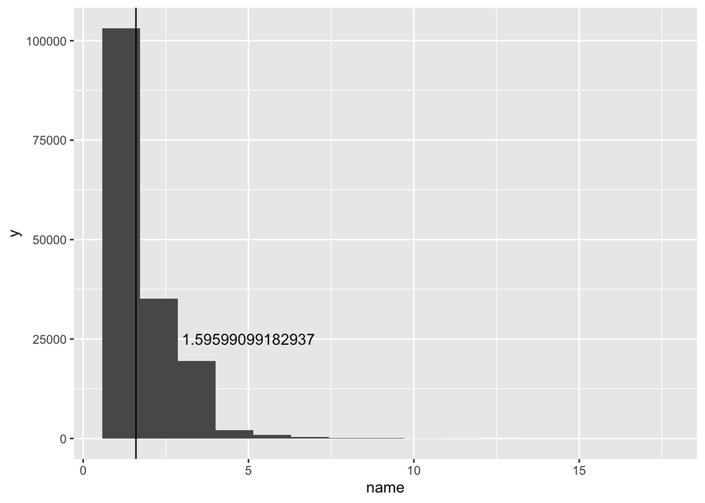

```r
ggplot(children1, aes(x = name)) +
  geom_histogram(bins = 15) +
  geom_vline(xintercept = mean) +
  annotate("text", x = 5, y = 25000, label = mean)
```

## c

```r
children2 <- children %>%
  group_by(ID) %>%
  summarize(count = n())
max(children2$count)
```

```
## [1] 12
```

The count column counts the number of times each ID appears and therefore shows how many times cases have appeared for them. Therefore the max of these counts, which is associated to one of the children’s ID’s is the maximum number of cases associated to one child.

## d

```r
payments %>%
  count(AP_ID) %>%
  arrange(AP_ID) %>%
  head()
```

```
##     AP_ID  n
## 1 1718626 10
## 2 1718628 36
## 3 1718629  5
## 4 1718630 15
## 5 1718631 18
## 6 1718643 36
```

```r
parents_payments <- payments %>%
  left_join(parents, by = "AP_ID") %>%
  count(AP_ID) %>%
  arrange(AP_ID)
head(parents_payments)
```

```
##     AP_ID  n
## 1 1718626 10
## 2 1718628 36
## 3 1718629  5
## 4 1718630 15
## 5 1718631 18
## 6 1718643 36
```

# 2

```r
pool_categories <- function(name,threshold){
  freq <- table(name)
  values <- freq[freq < threshold]
  if("Other" %in% levels(name)){
    stop("Other level already exists")
  }
  else{
    name <- ifelse(name %in% names(values),"Other", as.character(name))
    name <- factor(table(name))
  }
  return(name)
}
pool_categories(payments$PYMNT_SRC, 150)
```

```
##       A       C       F       G       I   Other       S       U       W
##   69144    2092    6690     513   19762     278    4305   50574 1356858
## Levels: 278 513 2092 4305 6690 19762 50574 69144 1356858
```

# 3.

## a.

```r
payments <- payments %>% mutate("DATE" = mdy_hms(COLLECTION_DT)) %>% arrange(DATE)
head(payments)
```

```
##    CASE_NUM PYMNT_AMT      COLLECTION_DT PYMNT_SRC PYMNT_TYPE   AP_ID
## 1 381388123     50.00   7/6/2002 0:00:00         A          C 1770778
## 2 381388123    160.00   8/5/2002 0:00:00         A          A 1770778
## 3 181384171      1.34  3/18/2005 0:00:00         A          C 1754083
## 4 121384407      0.72 10/27/2006 0:00:00         A          A 1726406
## 5 121384407      0.61 10/27/2006 0:00:00         A          A 1726406
## 6 691448592     28.13 12/18/2006 0:00:00         A          A 1720261
##         DATE
## 1 2002-07-06
## 2 2002-08-05
## 3 2005-03-18
## 4 2006-10-27
## 5 2006-10-27
## 6 2006-12-18
```

```r
#i.
c(payments$DATE[1], payments$DATE[nrow(payments)])
```

```
## [1] "2002-07-06 UTC" "2016-11-04 UTC"
```

```r
#ii.
100 * nrow(payments %>% filter(DATE < ymd(20150501))) / nrow(payments)
```

```
## [1] 0.381601
```

The range of dates of all payments is 2002-07-06 to 2016-11-04. The percentage of total payments made before May 1st, 2015 is 0.382.

## b.

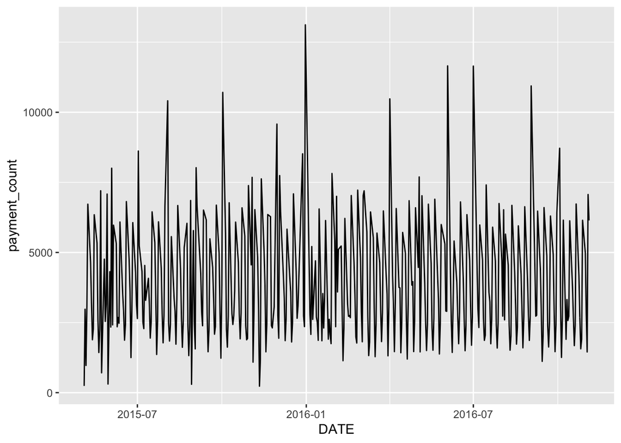

```r
payments2 <- payments %>% filter(DATE > ymd(20150501)) %>% group_by(DATE) %>% summarize("payment_count" = n())
ggplot(data = payments2, mapping = aes(x = DATE, y = payment_count)) +
  geom_line()
```

## c.

The bimodal shape of the distribution of payments made on each day over this time period is explained by the idea that payments are made either at the start of the month, or at the very end of the month. This is why we see frequent variation, as well as large peaks in the sequence plot of the data.

## d.

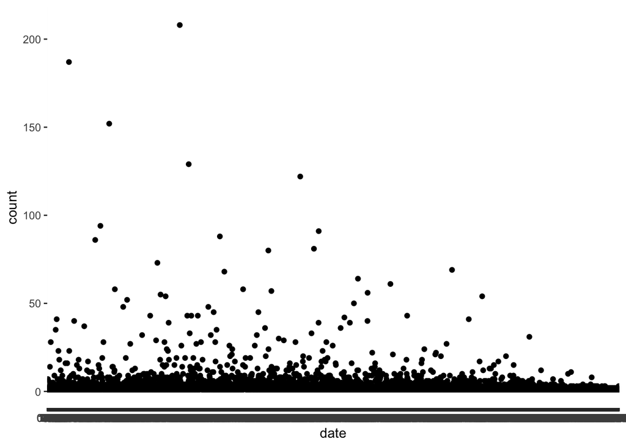

```r
payments4 <- payments %>% filter(DATE > ymd(20161101)) %>% group_by(PYMNT_AMT)
payments5 <- data.frame(table(payments4$PYMNT_AMT))
colnames(payments5) <- c('date', 'count')
ggplot(data = payments5, mapping = aes(x = date, y = count)) +
  geom_point()
```

# 4

## a

H01: There is no linear relationship between number of children and total amount of payments by the parent. HA1: There is some relationship between the number of children and total amount of payments made by the parent. H02: There is no linear relationship between number of children and number of payments by the parent. HA1: There is some relationship between the number of children and number of payments made by the parent.

```r
payment_sum <- payments %>%
  group_by(AP_ID) %>%
  summarize("payment_total" = sum(PYMNT_AMT))
payment_count <- payments %>%
  group_by(AP_ID) %>%
  summarize("payment_number" = n())
payments_distinct <- payments %>%
  distinct(CASE_NUM, AP_ID)
number_children <- payments_distinct %>%
  inner_join(children, by = "CASE_NUM") %>%
  group_by(CASE_NUM, AP_ID) %>%
  summarize("children_number" = n()) %>%
  arrange(children_number)
```

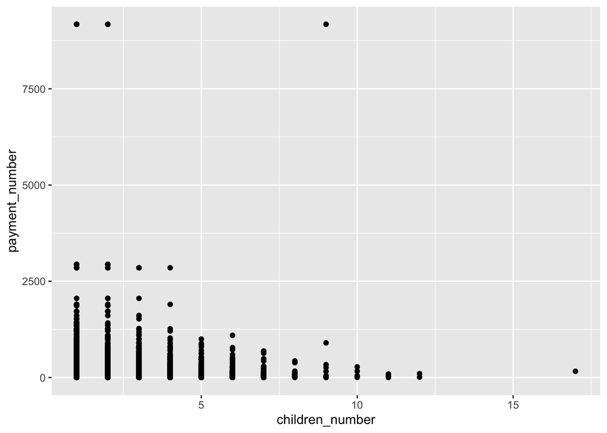

```r
all_set <- number_children %>%
  inner_join(payment_count, by = "AP_ID") %>%
  inner_join(payment_sum, by = "AP_ID") %>%
  replace(is.na(.), 0)
ggplot(all_set, aes(x = children_number, y = payment_number)) +
  geom_point()
```

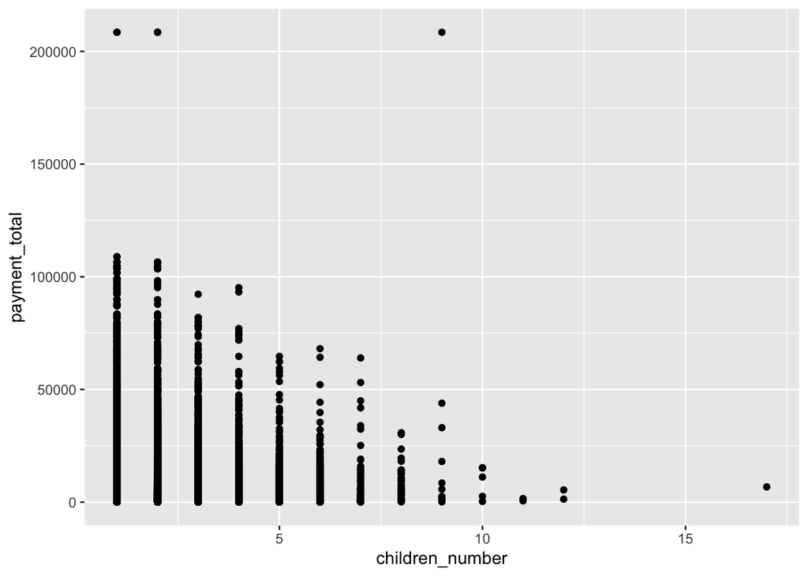

```r
ggplot(all_set, aes(x = children_number, y = payment_total)) +
  geom_point()
```

```r
summary(lm(payment_number~children_number, data = all_set))
```

```
##
## Call:
## lm(formula = payment_number ~ children_number, data = all_set)
##
## Residuals:
##    Min     1Q Median     3Q    Max
##  -95.2  -65.9  -43.3   -2.9 9097.1
##
## Coefficients:
##                 Estimate Std. Error t value Pr(>|t|)
## (Intercept)      78.1313     1.9907  39.248   <2e-16 ***
## children_number   1.7318     0.9962   1.738   0.0821 .
## ---
## Signif. codes:  0 '***' 0.001 '**' 0.01 '*' 0.05 '.' 0.1 ' ' 1
##
## Residual standard error: 197.6 on 34775 degrees of freedom
## Multiple R-squared:  8.69e-05,   Adjusted R-squared:  5.814e-05
## F-statistic: 3.022 on 1 and 34775 DF,  p-value: 0.08215
```

```r
par(mfrow = c(2,2))
plot(lm(payment_number~children_number, data = all_set))
summary(lm(payment_total~children_number, data = all_set))
```

```
##
## Call:
## lm(formula = payment_total ~ children_number, data = all_set)
##
## Residuals:
##    Min     1Q Median     3Q    Max
##  -8078  -6533  -3743   1542 200614
##
## Coefficients:
##                 Estimate Std. Error t value Pr(>|t|)
## (Intercept)      8101.71     116.99  69.250   <2e-16 ***
## children_number   -23.65      58.54  -0.404    0.686
## ---
## Signif. codes:  0 '***' 0.001 '**' 0.01 '*' 0.05 '.' 0.1 ' ' 1
##
## Residual standard error: 11610 on 34775 degrees of freedom
## Multiple R-squared:  4.692e-06,  Adjusted R-squared:  -2.406e-05
## F-statistic: 0.1632 on 1 and 34775 DF,  p-value: 0.6863
```

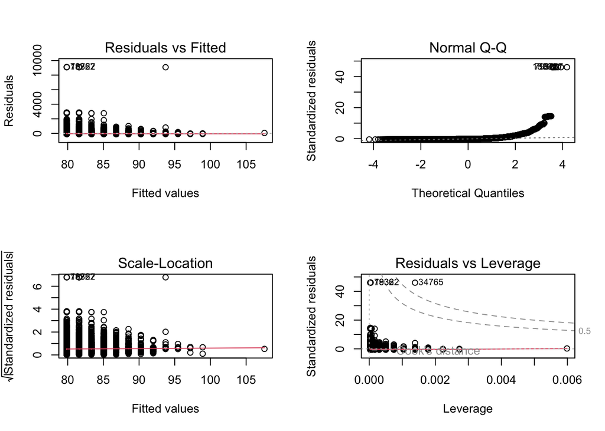

```r
par(mfrow = c(2,2))
plot(lm(payment_number~children_number, data = all_set))
```

```r
cor.test(all_set$children_number, all_set$payment_number)
```

```
##
##  Pearson's product-moment correlation
##
## data:  all_set$children_number and all_set$payment_number
## t = 1.7384, df = 34775, p-value = 0.08215
## alternative hypothesis: true correlation is not equal to 0
## 95 percent confidence interval:
##  -0.001188328  0.019829945
## sample estimates:
##         cor
## 0.009321838
```

```r
cor.test(all_set$children_number, all_set$payment_total)
```

```
##
##  Pearson's product-moment correlation
##
## data:  all_set$children_number and all_set$payment_total
## t = -0.40393, df = 34775, p-value = 0.6863
## alternative hypothesis: true correlation is not equal to 0
## 95 percent confidence interval:
##  -0.012675826  0.008344175
## sample estimates:
##          cor
## -0.002166065
```

The p-values from the correlation test shows us that we cannot reject the hypothesis that the correlation is 0 for both the number of payments and the total amount paid. This means that parents that are responsible for more children don’t pay more money or pay more frequently.

## b

H0: There is no linear relationship between the mean age of children and the total amount that their parent paid. HA: There is a linear relationship between the mean age of children and the total amount that their parent paid.

```r
children_date <- children %>%
  mutate("DOB" = mdy_hms(DATE_OF_BIRTH_DT))
date <- mdy_hms("01/01/2017 0:00:00")
children_date <-children_date %>%
  mutate("age" = as.numeric(date - DOB)) %>%
  left_join(payments, by = "CASE_NUM") %>%
  group_by(AP_ID) %>%
  summarize("mean_age" = mean(age))
sum <- payments %>%
  left_join(children, by = "CASE_NUM") %>%
  group_by(AP_ID) %>%
  summarize("total_payments" = sum(PYMNT_AMT))
sum
```

```
## # A tibble: 28,579 × 2
##      AP_ID total_payments
##      <int>          <dbl>
##  1 1718626          5175.
##  2 1718628          9360
##  3 1718629          5512.
##  4 1718630          2186.
##  5 1718631          1195.
##  6 1718643          7254
##  7 1718656          1168.
##  8 1718658          3942
##  9 1718659           949.
## 10 1718661            40
## # … with 28,569 more rows
```

```r
mean_payments <- children_date %>%
  inner_join(sum, by = "AP_ID") %>%
  replace(is.na(.), 0)
summary(lm(total_payments~mean_age, data = mean_payments))
```

```
##
## Call:
## lm(formula = total_payments ~ mean_age, data = mean_payments)
##
## Residuals:
##    Min     1Q Median     3Q    Max
## -13540  -8028  -5201   1320 526100
##
## Coefficients:
##               Estimate Std. Error t value Pr(>|t|)
## (Intercept)  1.356e+04  2.269e+02   59.77   <2e-16 ***
## mean_age    -5.137e-01  3.324e-02  -15.45   <2e-16 ***
## ---
## Signif. codes:  0 '***' 0.001 '**' 0.01 '*' 0.05 '.' 0.1 ' ' 1
##
## Residual standard error: 16530 on 27963 degrees of freedom
## Multiple R-squared:  0.008468,   Adjusted R-squared:  0.008433
## F-statistic: 238.8 on 1 and 27963 DF,  p-value: < 2.2e-16
```

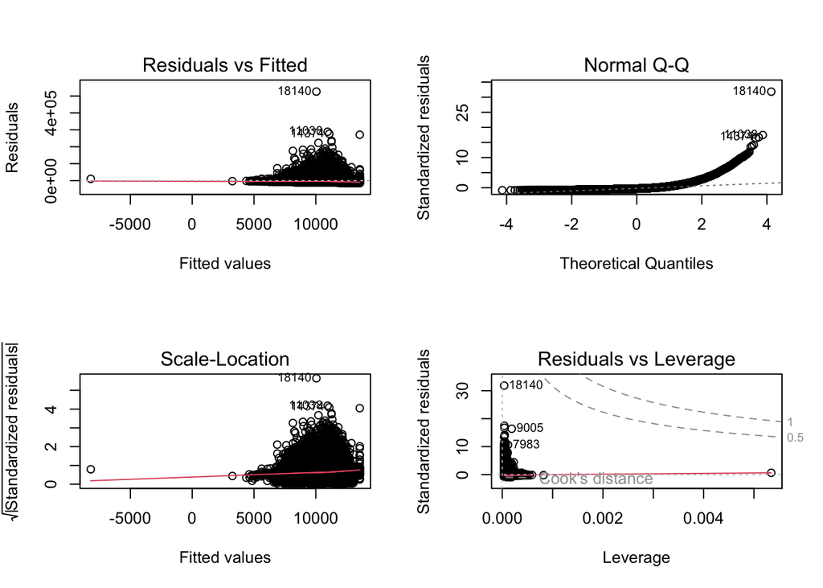

```r
par(mfrow = c(2,2))
plot(lm(total_payments~mean_age, data = mean_payments))
```

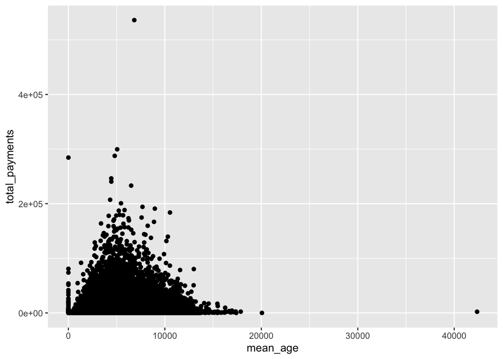

```r
ggplot(mean_payments, aes(x = mean_age, y = total_payments))+
  geom_point()
```

```r
cor.test(mean_payments$mean_age, mean_payments$total_payments)
```

```
##
##  Pearson's product-moment correlation
##
## data:  mean_payments$mean_age and mean_payments$total_payments
## t = -15.454, df = 27963, p-value < 2.2e-16
## alternative hypothesis: true correlation is not equal to 0
## 95 percent confidence interval:
##  -0.10363177 -0.08038936
## sample estimates:
##        cor
## -0.0920231
```

The correlation test shows us that we can reject the null hypothesis that there is no linear correlation between mean age and total payments. However, even though there is a correlation, the correlation is very weak and negative.

## c

H0: Zip code of the absent parent does not anticipate the total payment amount. HA: Zip code of the absent parent does anticipate the total payment amount.

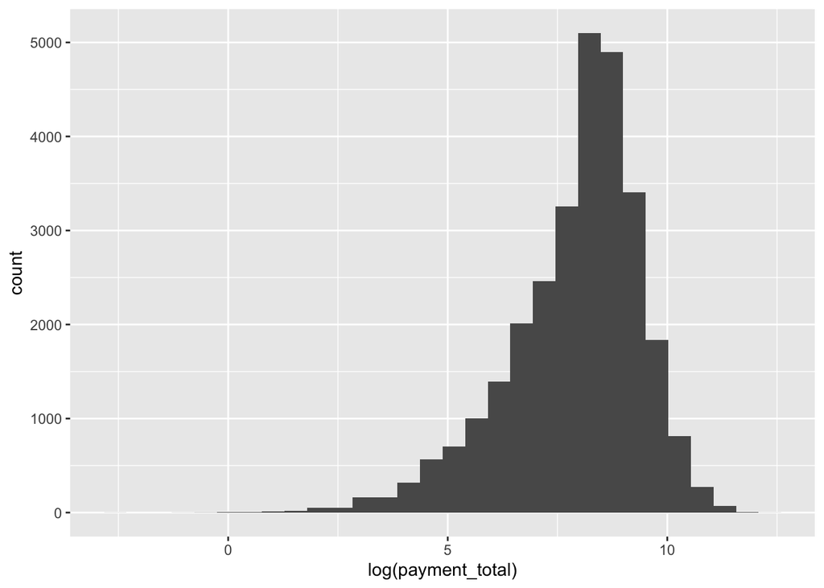

```r
zip <- payment_sum %>%
  left_join(parents, by = "AP_ID") %>%
  select(AP_ID,payment_total, AP_ADDR_ZIP)
ggplot(zip, aes(x = log(payment_total))) +
  geom_histogram()
```

```r
zip.sd <- zip %>%
  group_by(AP_ADDR_ZIP) %>%
  summarize("sd" = sd(payment_total))
max(zip.sd$sd)/ min(zip.sd$sd)
```

```
## [1] 1.618833
```

```r
one.way <- aov(log(payment_total) ~ AP_ADDR_ZIP, data = zip)
summary(one.way)
```

```
##                Df Sum Sq Mean Sq F value Pr(>F)
## AP_ADDR_ZIP     5    520  103.93   45.82 <2e-16 ***
## Residuals   28573  64812    2.27
## ---
## Signif. codes:  0 '***' 0.001 '**' 0.01 '*' 0.05 '.' 0.1 ' ' 1
```

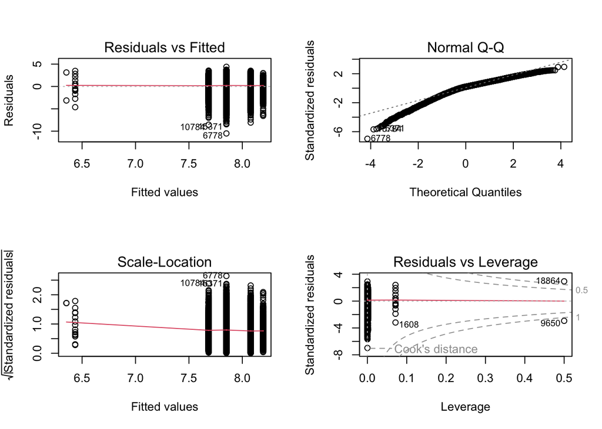

```r
par(mfrow = c(2,2))
plot(one.way)
```

Since the p-value is less than 2e-16, we can reject the null hypothesis that zip code does not anticipate the total payments.

## d

H0: Number of children and mean age of the children have no linear relationship with the total payment made by parents. HA: Number of children and mean age of the children has a relationship with the total payment made by parents.

```r
complete_set <- all_set %>%
  left_join(mean_payments, by = "AP_ID")
multiple_model<-lm(payment_total ~ children_number*mean_age, data = complete_set)
summary(multiple_model)
```

```
##
## Call:
## lm(formula = payment_total ~ children_number * mean_age, data = complete_set)
##
## Residuals:
##    Min     1Q Median     3Q    Max
## -10637  -6058  -3660   1489 200712
##
## Coefficients:
##                            Estimate Std. Error t value Pr(>|t|)
## (Intercept)               1.086e+04  2.812e+02  38.622   <2e-16 ***
## children_number          -2.054e+02  1.507e+02  -1.362    0.173
## mean_age                 -4.516e-01  4.157e-02 -10.863   <2e-16 ***
## children_number:mean_age  3.203e-02  2.240e-02   1.430    0.153
## ---
## Signif. codes:  0 '***' 0.001 '**' 0.01 '*' 0.05 '.' 0.1 ' ' 1
##
## Residual standard error: 11550 on 34773 degrees of freedom
## Multiple R-squared:  0.01001,    Adjusted R-squared:  0.009921
## F-statistic: 117.2 on 3 and 34773 DF,  p-value: < 2.2e-16
```

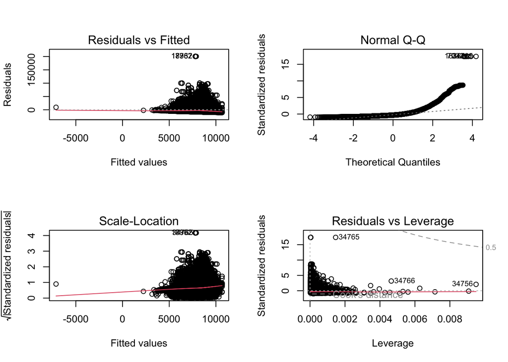

```r
par(mfrow = c(2,2))
plot(multiple_model)
```

```r
summary(aov(multiple_model))
```

```
##                             Df    Sum Sq   Mean Sq F value Pr(>F)
## children_number              1 2.200e+07 2.200e+07   0.165  0.685
## mean_age                     1 4.662e+10 4.662e+10 349.259 <2e-16 ***
## children_number:mean_age     1 2.731e+08 2.731e+08   2.046  0.153
## Residuals                34773 4.641e+12 1.335e+08
## ---
## Signif. codes:  0 '***' 0.001 '**' 0.01 '*' 0.05 '.' 0.1 ' ' 1
```

Since p-value for the Global Null Hypothesis is less than 2.2e-16, we can say that there is a linear relationship between mean age or number of children on total payments. In this case, we see that the relationship is between mean age of the children and the total payments made by the parent.

# 5

## a

H0: There is no linear association between the standard deviation of total payments and the mean of total payments. HA: There is a linear association between the standard deviation of total payments and the mean of total payments.

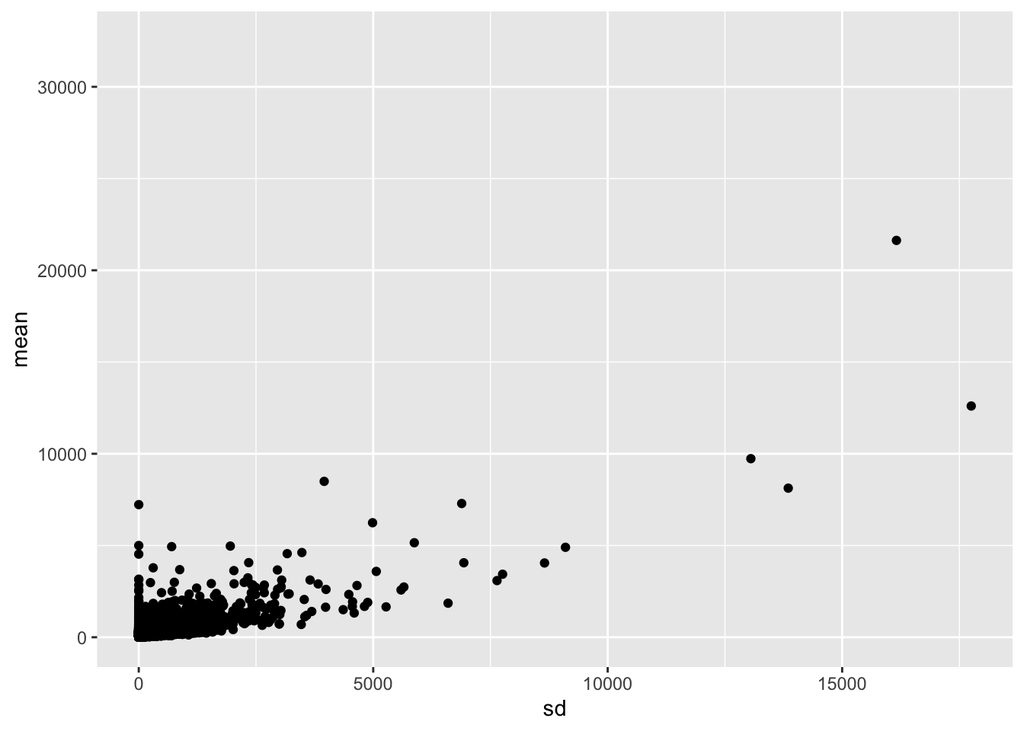

```r
daily_sd <- payments %>%
  group_by(AP_ID) %>%
  summarize("sd" = sd(PYMNT_AMT))
daily_mean <- payments %>%
  group_by(AP_ID) %>%
  summarize("mean" = mean(PYMNT_AMT))
daily_sd_mean <- daily_sd %>%
  left_join(daily_mean, by = "AP_ID")
ggplot(daily_sd_mean, aes(x = sd, y = mean)) +
  geom_point()
```

```r
sd_mean_model <- lm(mean~sd, data = daily_sd_mean)
summary(sd_mean_model)
```

```
##
## Call:
## lm(formula = mean ~ sd, data = daily_sd_mean)
##
## Residuals:
##     Min      1Q  Median      3Q     Max
## -2531.0   -68.9   -30.1    33.4 11027.7
##
## Coefficients:
##              Estimate Std. Error t value Pr(>|t|)
## (Intercept) 1.012e+02  1.240e+00   81.63   <2e-16 ***
## sd          6.498e-01  3.464e-03  187.57   <2e-16 ***
## ---
## Signif. codes:  0 '***' 0.001 '**' 0.01 '*' 0.05 '.' 0.1 ' ' 1
##
## Residual standard error: 195.9 on 27230 degrees of freedom
##   (1347 observations deleted due to missingness)
## Multiple R-squared:  0.5637, Adjusted R-squared:  0.5637
## F-statistic: 3.518e+04 on 1 and 27230 DF,  p-value: < 2.2e-16
```

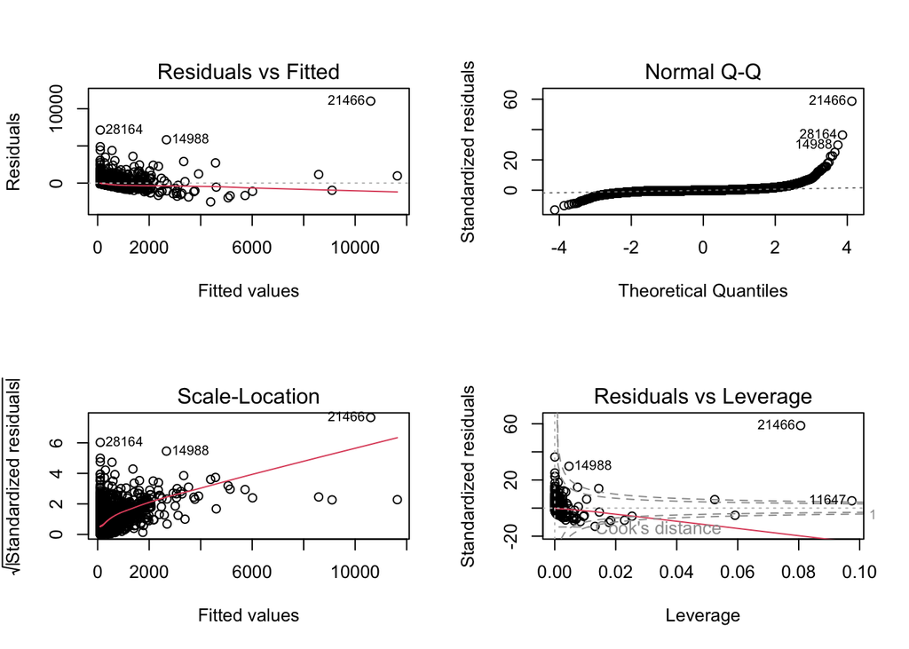

```r
par(mfrow = c(2,2))
plot(sd_mean_model)
```

```r
cor.test(daily_sd_mean$sd, daily_sd_mean$mean)
```

```
##
##  Pearson's product-moment correlation
##
## data:  daily_sd_mean$sd and daily_sd_mean$mean
## t = 187.57, df = 27230, p-value < 2.2e-16
## alternative hypothesis: true correlation is not equal to 0
## 95 percent confidence interval:
##  0.7455779 0.7559425
## sample estimates:
##       cor
## 0.7508064
```

The p-value of the correlation test is less than our threshold of 0.05. This means that there is a correlation between the SD of payments and the mean of the payments. This correlation is strong and positive.

## b

```r
paymentsCV <- payments %>% group_by(AP_ID) %>% summarize("CV" = sd(PYMNT_AMT)/mean(PYMNT_AMT))
paymentsCV <- na.omit(paymentsCV)
low <- quantile(paymentsCV$CV, (0.25))
medium <- quantile(paymentsCV$CV, (0.5))
high <- quantile(paymentsCV$CV, (0.75))
paymentsCVlow <- paymentsCV %>% filter(CV <= low) %>% arrange(desc(CV))
paymentsCVlowAPID <- paymentsCVlow[1,1]

paymentsCVmedium <- paymentsCV %>% filter(CV <=  medium) %>% arrange(desc(CV))
paymentsCVmediumAPID <- paymentsCVmedium[1,1]

paymentsCVhigh <- paymentsCV %>% filter(CV <= high) %>% arrange(desc(CV))
paymentsCVhighAPID <- paymentsCVhigh[1,1]

paymentsCVlowAPID #parent with low CV has AP_ID: 1775478
```

```
## # A tibble: 1 × 1
##     AP_ID
##     <int>
## 1 1775478
```

```r
paymentsCVmediumAPID #parent with medium CV has AP_ID: 1757513
```

```
## # A tibble: 1 × 1
##     AP_ID
##     <int>
## 1 1757513
```

```r
paymentsCVhighAPID #parent with high CV has AP_ID: 1769077
```

```
## # A tibble: 1 × 1
##     AP_ID
##     <int>
## 1 1769077
```

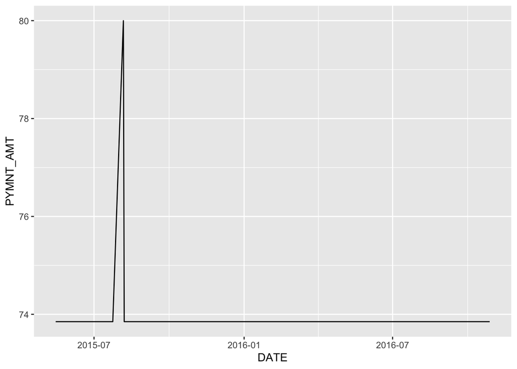

```r
lowDf <- payments %>% filter(AP_ID == 1775478) %>% group_by(DATE)
ggplot(data = lowDf, mapping = aes(x = DATE, y = PYMNT_AMT)) +
  geom_line()
```

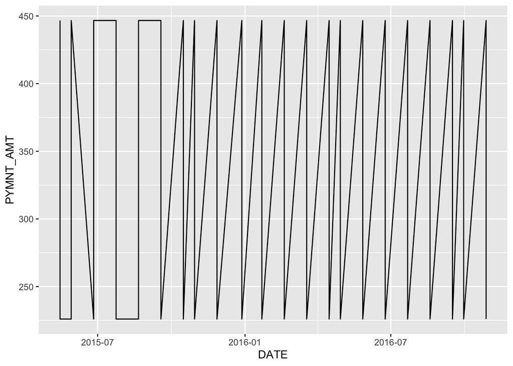

```r
mediumDf <- payments %>% filter(AP_ID == 1757513) %>% group_by(DATE)
ggplot(data = mediumDf, mapping = aes(x = DATE, y = PYMNT_AMT)) +
  geom_line()
```

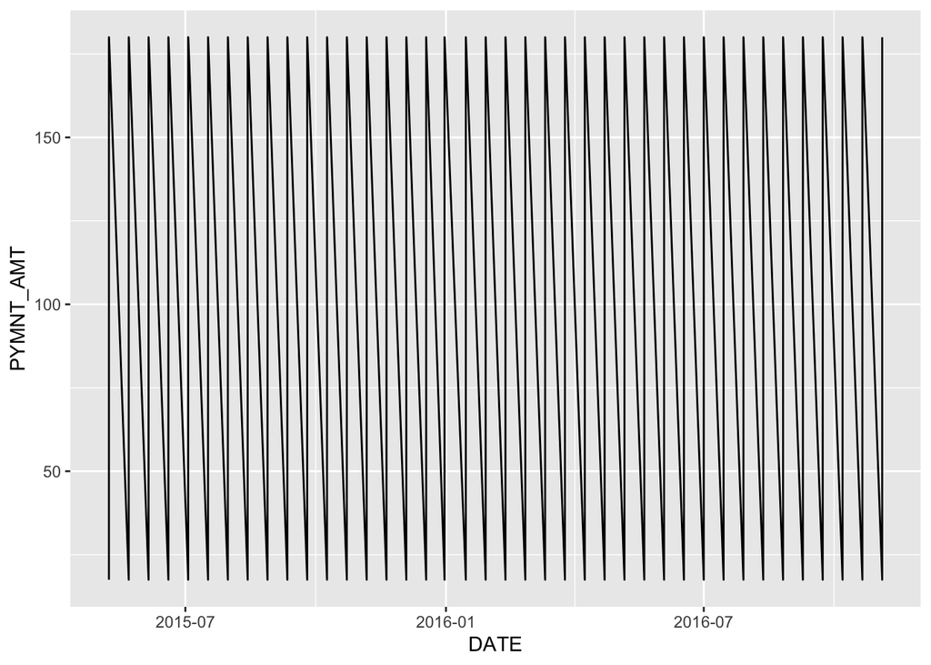

```r
highDf <- payments %>% filter(AP_ID == 1769077) %>% group_by(DATE)
ggplot(data = highDf, mapping = aes(x = DATE, y = PYMNT_AMT)) +
  geom_line()
```

## c

H0: There is no linear relationship between the CV and the total payments. HA: There is a a linear relationship between the CV and the total payments.

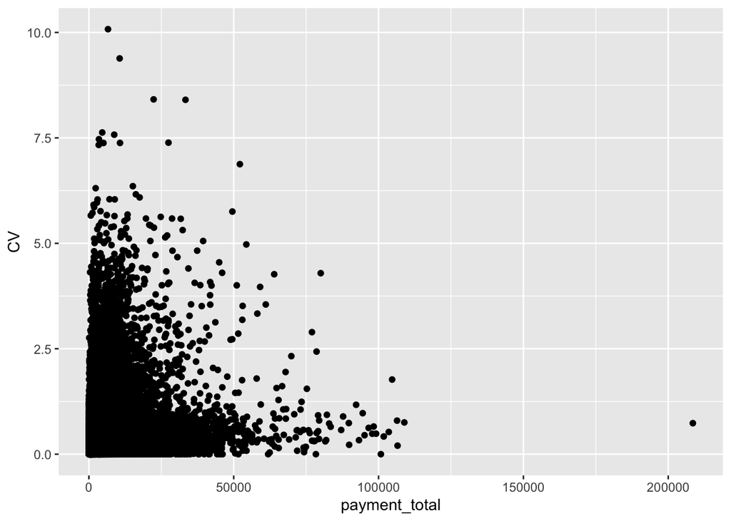

```r
payments_CV_total <- paymentsCV %>%
  left_join(payment_sum, by = "AP_ID")
ggplot(payments_CV_total, aes(x = payment_total, y = CV))+
  geom_point()
```

```r
CV_model <- lm(CV~payment_total, data = payments_CV_total)
summary(CV_model)
```

```
##
## Call:
## lm(formula = CV ~ payment_total, data = payments_CV_total)
##
## Residuals:
##     Min      1Q  Median      3Q     Max
## -1.6885 -0.4870 -0.2162  0.1745  9.5334
##
## Coefficients:
##                Estimate Std. Error t value Pr(>|t|)
## (Intercept)   4.831e-01  5.570e-03   86.72   <2e-16 ***
## payment_total 9.306e-06  5.335e-07   17.44   <2e-16 ***
## ---
## Signif. codes:  0 '***' 0.001 '**' 0.01 '*' 0.05 '.' 0.1 ' ' 1
##
## Residual standard error: 0.7353 on 27230 degrees of freedom
## Multiple R-squared:  0.01105,    Adjusted R-squared:  0.01101
## F-statistic: 304.2 on 1 and 27230 DF,  p-value: < 2.2e-16
```

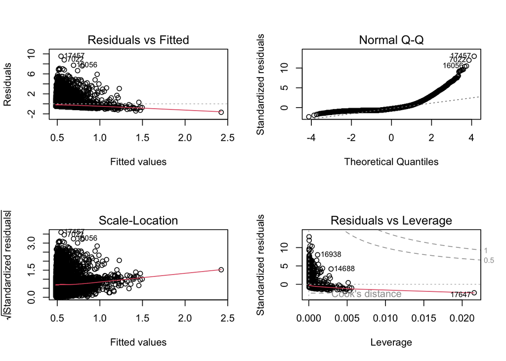

```r
par(mfrow = c(2,2))
plot(CV_model)
```

```r
cor.test(payments_CV_total$CV, payments_CV_total$payment_total)
```

```
##
##  Pearson's product-moment correlation
##
## data:  payments_CV_total$CV and payments_CV_total$payment_total
## t = 17.443, df = 27230, p-value < 2.2e-16
## alternative hypothesis: true correlation is not equal to 0
## 95 percent confidence interval:
##  0.09335745 0.11684928
## sample estimates:
##      cor
## 0.105118
```

Since the p-value is less than our threshold of 0.05, we can reject the null hypothesis. Even though there is a correlation, it is very weak at around 0.11.

## d (BONUS)

```r
paymsum <- payments %>% na.omit() %>% group_by(DATE, AP_ID) %>% summarize(dailysumtot = sum(PYMNT_AMT)) #DATE in group_by before AP_ID
SDsummary <- paymsum %>% group_by(DATE) %>% summarize(newSd = sd(dailysumtot, na.rm = TRUE))#DATE in group_by before AP_ID

newmean <- mean(paymsum$dailysumtot)
#SDsummary <- paymsum %>% filter(n()>1) %>% summarize(mean = mean(, na.rm = TRUE))

SDsummary %>% mutate(newcv = (newSd/newmean)) %>% head()
```

```
## # A tibble: 6 × 3
##   DATE                newSd newcv
##   <dttm>              <dbl> <dbl>
## 1 2002-07-06 00:00:00    NA    NA
## 2 2002-08-05 00:00:00    NA    NA
## 3 2005-03-18 00:00:00    NA    NA
## 4 2006-10-27 00:00:00    NA    NA
## 5 2006-12-18 00:00:00    NA    NA
## 6 2009-08-27 00:00:00    NA    NA
```

```r
(SDsum2 <- SDsummary %>% mutate(newcv = (newSd/newmean)) %>% mutate(rank = newcv < 0.5) %>% head())
```

```
## # A tibble: 6 × 4
##   DATE                newSd newcv rank
##   <dttm>              <dbl> <dbl> <lgl>
## 1 2002-07-06 00:00:00    NA    NA NA
## 2 2002-08-05 00:00:00    NA    NA NA
## 3 2005-03-18 00:00:00    NA    NA NA
## 4 2006-10-27 00:00:00    NA    NA NA
## 5 2006-12-18 00:00:00    NA    NA NA
## 6 2009-08-27 00:00:00    NA    NA NA
```

```r
(newcvattr <- left_join(payments, SDsum2, by="DATE") %>% mutate(newcv = newSd/newmean) %>% head()) #by = "DATE"
```

```
##    CASE_NUM PYMNT_AMT      COLLECTION_DT PYMNT_SRC PYMNT_TYPE   AP_ID
## 1 381388123     50.00   7/6/2002 0:00:00         A          C 1770778
## 2 381388123    160.00   8/5/2002 0:00:00         A          A 1770778
## 3 181384171      1.34  3/18/2005 0:00:00         A          C 1754083
## 4 121384407      0.72 10/27/2006 0:00:00         A          A 1726406
## 5 121384407      0.61 10/27/2006 0:00:00         A          A 1726406
## 6 691448592     28.13 12/18/2006 0:00:00         A          A 1720261
##         DATE newSd newcv rank
## 1 2002-07-06    NA    NA   NA
## 2 2002-08-05    NA    NA   NA
## 3 2005-03-18    NA    NA   NA
## 4 2006-10-27    NA    NA   NA
## 5 2006-10-27    NA    NA   NA
## 6 2006-12-18    NA    NA   NA
```

```r
#rank = AP_ID + PYMNT_SRC + DATE + CASE_NUM + PYMNT_AMT + PRINT_TYPE
#summary(rank, data = newcvattr) # + DATE
```